# Clean and more accurate results with converted features

In this project, I tried to differentiate from other examples as much as I can, especially in the data cleaning part. But as long as the dataset is the same and most effective approaches were already studied, there are of course similarities with other Kernels, in other words it is just another example as good as everyone's work, thank you for checking in advance!

With this study I got 0.12135% Score, but I tried already trained ML models in this work with more complex Model Combination methods like adding a meta-model on averaged base models and it generated better results with around 10%-11%. But I decided not to put them, because I want to improve my expertise on these methods before tring to explain.

```python
import os
import pandas as pd
import matplotlib.pyplot as plt
import numpy as np
import seaborn as sns
```

```python
os.chdir("E:/dersler/Practicum 1/assignment 2-3")
```

## Reading and cleaning data and Exploratory Data Analysis

At first I imported both train and test dataset into different dataframes and merged them, which is going to help me in cleaning part.

```python
train = pd.read_csv("train.csv")
train.info()
```

```
<class 'pandas.core.frame.DataFrame'>
RangeIndex: 1460 entries, 0 to 1459
Data columns (total 81 columns):
Id               1460 non-null int64
MSSubClass       1460 non-null int64
MSZoning         1460 non-null object
LotFrontage      1201 non-null float64
LotArea          1460 non-null int64
Street           1460 non-null object
Alley            91 non-null object
LotShape         1460 non-null object
LandContour      1460 non-null object
Utilities        1460 non-null object
LotConfig        1460 non-null object
LandSlope        1460 non-null object
Neighborhood     1460 non-null object
Condition1       1460 non-null object
Condition2       1460 non-null object
BldgType         1460 non-null object
HouseStyle       1460 non-null object
OverallQual      1460 non-null int64
OverallCond      1460 non-null int64
YearBuilt        1460 non-null int64
YearRemodAdd     1460 non-null int64
RoofStyle        1460 non-null object
RoofMatl         1460 non-null object
Exterior1st      1460 non-null object
Exterior2nd      1460 non-null object
MasVnrType       1452 non-null object
MasVnrArea       1452 non-null float64
ExterQual        1460 non-null object
ExterCond        1460 non-null object
Foundation       1460 non-null object
BsmtQual         1423 non-null object
BsmtCond         1423 non-null object
BsmtExposure     1422 non-null object
BsmtFinType1     1423 non-null object
BsmtFinSF1       1460 non-null int64
BsmtFinType2     1422 non-null object
BsmtFinSF2       1460 non-null int64
```

[output cut: 31 more lines]

```
EnclosedPorch    1460 non-null int64
3SsnPorch        1460 non-null int64
ScreenPorch      1460 non-null int64
PoolArea         1460 non-null int64
PoolQC           7 non-null object
Fence            281 non-null object
MiscFeature      54 non-null object
MiscVal          1460 non-null int64
MoSold           1460 non-null int64
YrSold           1460 non-null int64
SaleType         1460 non-null object
SaleCondition    1460 non-null object
SalePrice        1460 non-null int64
dtypes: float64(3), int64(35), object(43)
memory usage: 924.0+ KB
```

```python
test=pd.read_csv("test.csv")
test.info()
```

```
<class 'pandas.core.frame.DataFrame'>
RangeIndex: 1459 entries, 0 to 1458
Data columns (total 80 columns):
Id               1459 non-null int64
MSSubClass       1459 non-null int64
MSZoning         1455 non-null object
LotFrontage      1232 non-null float64
LotArea          1459 non-null int64
Street           1459 non-null object
Alley            107 non-null object
LotShape         1459 non-null object
LandContour      1459 non-null object
Utilities        1457 non-null object
LotConfig        1459 non-null object
LandSlope        1459 non-null object
Neighborhood     1459 non-null object
Condition1       1459 non-null object
Condition2       1459 non-null object
BldgType         1459 non-null object
HouseStyle       1459 non-null object
OverallQual      1459 non-null int64
OverallCond      1459 non-null int64
YearBuilt        1459 non-null int64
YearRemodAdd     1459 non-null int64
RoofStyle        1459 non-null object
RoofMatl         1459 non-null object
Exterior1st      1458 non-null object
Exterior2nd      1458 non-null object
MasVnrType       1443 non-null object
MasVnrArea       1444 non-null float64
ExterQual        1459 non-null object
ExterCond        1459 non-null object
Foundation       1459 non-null object
BsmtQual         1415 non-null object
BsmtCond         1414 non-null object
BsmtExposure     1415 non-null object
BsmtFinType1     1417 non-null object
BsmtFinSF1       1458 non-null float64
BsmtFinType2     1417 non-null object
BsmtFinSF2       1458 non-null float64
```

[output cut: 30 more lines]

```
OpenPorchSF      1459 non-null int64
EnclosedPorch    1459 non-null int64
3SsnPorch        1459 non-null int64
ScreenPorch      1459 non-null int64
PoolArea         1459 non-null int64
PoolQC           3 non-null object
Fence            290 non-null object
MiscFeature      51 non-null object
MiscVal          1459 non-null int64
MoSold           1459 non-null int64
YrSold           1459 non-null int64
SaleType         1458 non-null object
SaleCondition    1459 non-null object
dtypes: float64(11), int64(26), object(43)
memory usage: 912.0+ KB
```

```python
trainnum = train._get_numeric_data()
```

```python
traincat = train.drop(trainnum.columns, axis=1)
```

Since only the train data has included SalePrice data, I separated them into categorical and numeric and then plot their relation with the target variable(SalePrice). For the categorical variables, for understanding the range more clearly, I took log of SalePrice. It allowed me to see the differences btw. different categories more clearly.

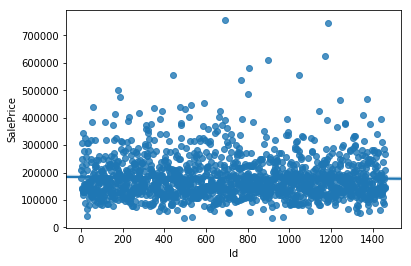

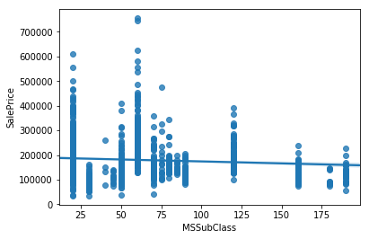

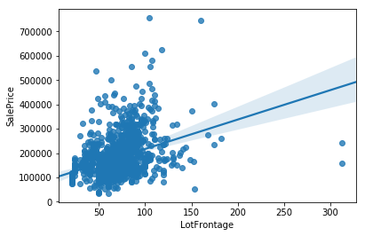

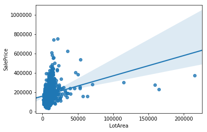

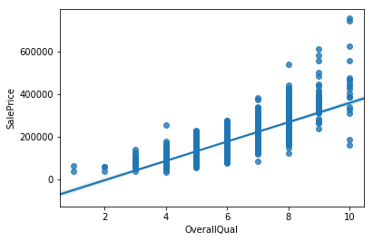

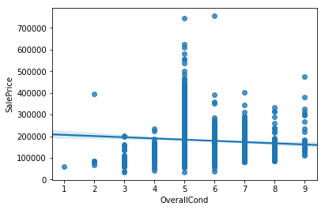

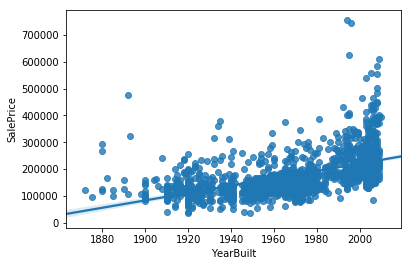

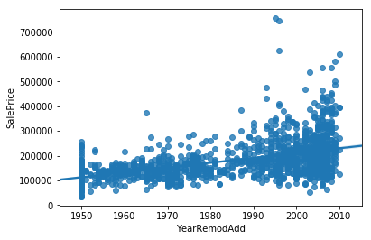

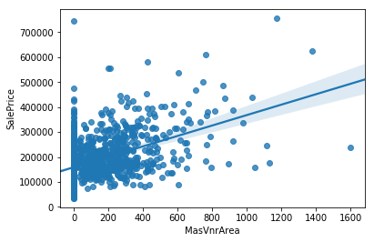

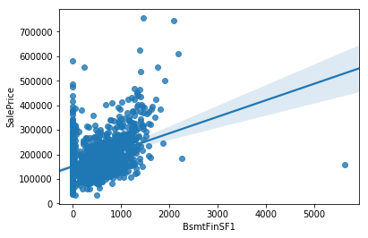

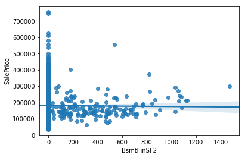

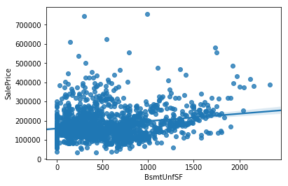

[25 more figures not shown]

```python
for x in trainnum.drop('SalePrice', axis=1).columns:
    sns.regplot(x, "SalePrice", data=trainnum)
    plt.xlabel(x)
    plt.ylabel("SalePrice")
    plt.show()
```

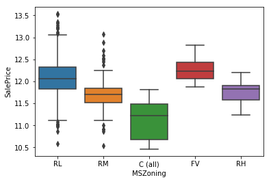

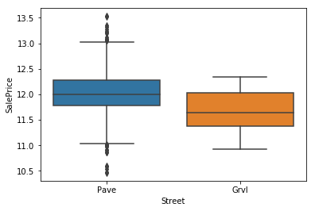

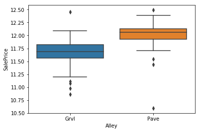

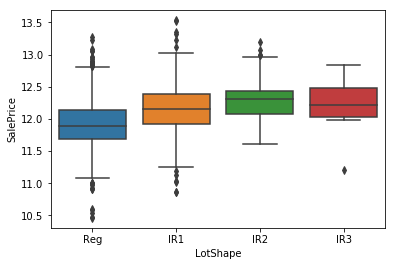

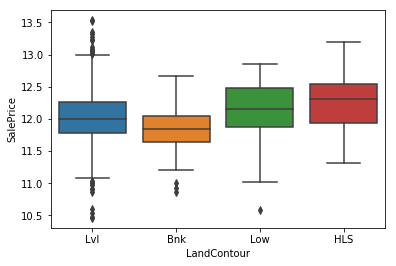

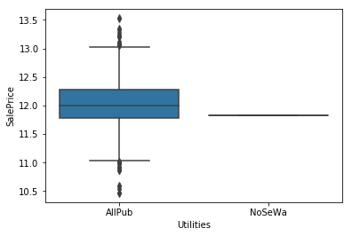

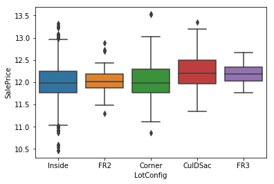

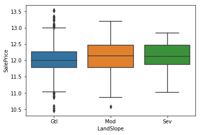

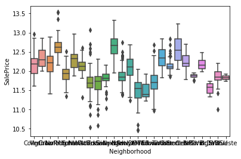

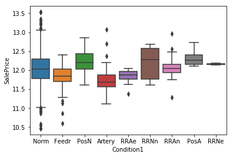

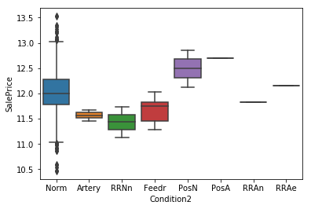

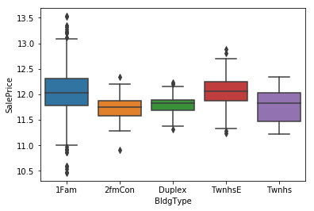

[31 more figures not shown]

```python
for x in traincat.columns:
    sns.boxplot(x, np.log(train.SalePrice), data=traincat)
    plt.xlabel(x)
    plt.ylabel("SalePrice")
    plt.show()
```

Due to comparison graphs of categorical variables, most of them seems as expected. For example regarding to anyone of the Quality variables Excellent conditions corresponds to higher prices. However, I wolud like to mention that I saw among them as little unexpected results; it shows that "Utilities" dataset doesn't carry a useful information at all, because almost all of observations are in same category. Moreover BsmtFinType1 and 2 variables did not affect SalePrice that much. However I will keep them anyway because one from each category has little effects. But I am going to drop Utilities variable.

After that, I will check the nr of missing values in each variable and correlations btw SalePrice and other numerical variables.

```python
total = pd.concat([train, test], sort=False).set_index('Id')
```

```python
total.isnull().sum()
```

```
MSSubClass          0
MSZoning            4
LotFrontage       486
LotArea             0
Street              0
Alley            2721
LotShape            0
LandContour         0
Utilities           2
LotConfig           0
LandSlope           0
Neighborhood        0
Condition1          0
Condition2          0
BldgType            0
HouseStyle          0
OverallQual         0
OverallCond         0
YearBuilt           0
YearRemodAdd        0
RoofStyle           0
RoofMatl            0
Exterior1st         1
Exterior2nd         1
MasVnrType         24
MasVnrArea         23
ExterQual           0
ExterCond           0
Foundation          0
BsmtQual           81
                 ...
BedroomAbvGr        0
KitchenAbvGr        0
KitchenQual         1
TotRmsAbvGrd        0
Functional          2
Fireplaces          0
FireplaceQu      1420
GarageType        157
GarageYrBlt       159
GarageFinish      159
GarageCars          1
GarageArea          1
GarageQual        159
GarageCond        159
PavedDrive          0
WoodDeckSF          0
OpenPorchSF         0
EnclosedPorch       0
3SsnPorch           0
ScreenPorch         0
PoolArea            0
PoolQC           2909
Fence            2348
MiscFeature      2814
MiscVal             0
MoSold              0
YrSold              0
SaleType            1
SaleCondition       0
SalePrice        1459
Length: 80, dtype: int64
```

```python
for col in trainnum.drop(['Id', 'SalePrice'],axis=1).columns :
    if (abs(train.SalePrice.corr(trainnum[col]))>0.2):
        print('Correlation btw SalePrice vs',trainnum[col].name, ':', round(train.SalePrice.corr(trainnum[col]),2))
```

```
Correlation btw SalePrice vs LotFrontage : 0.35
Correlation btw SalePrice vs LotArea : 0.26
Correlation btw SalePrice vs OverallQual : 0.79
Correlation btw SalePrice vs YearBuilt : 0.52
Correlation btw SalePrice vs YearRemodAdd : 0.51
Correlation btw SalePrice vs MasVnrArea : 0.48
Correlation btw SalePrice vs BsmtFinSF1 : 0.39
Correlation btw SalePrice vs BsmtUnfSF : 0.21
Correlation btw SalePrice vs TotalBsmtSF : 0.61
Correlation btw SalePrice vs 1stFlrSF : 0.61
Correlation btw SalePrice vs 2ndFlrSF : 0.32
Correlation btw SalePrice vs GrLivArea : 0.71
Correlation btw SalePrice vs BsmtFullBath : 0.23
Correlation btw SalePrice vs FullBath : 0.56
Correlation btw SalePrice vs HalfBath : 0.28
Correlation btw SalePrice vs TotRmsAbvGrd : 0.53
Correlation btw SalePrice vs Fireplaces : 0.47
Correlation btw SalePrice vs GarageYrBlt : 0.49
Correlation btw SalePrice vs GarageCars : 0.64
Correlation btw SalePrice vs GarageArea : 0.62
Correlation btw SalePrice vs WoodDeckSF : 0.32
Correlation btw SalePrice vs OpenPorchSF : 0.32
```

Since the correlation between to variable means one's effect to the compared one, the higher correlation resulted with a strong relation between variables regardless its sign(+/-). So I printed higher correlations than 0.2 to see which variable has stronger affect on SalePrice. It seems according to the results, OverallQual got the highest score of 0.79, in other words the most important one in terms of its affect on SalePrice. However it may change after variable transformation.

## Dealing with Missing Data

At this stage, I coppied original dataset and tried to do some feature transformations on it. Since "data is expensive" argument is valid, I tried to find some solutions to fill Null cells in order to keep the dataset still unless it has not any affect or possibility to mislead my prediction models. And when dealing with this, I got help from data explanations in the information page of the competition.

For example regarding some variables, as explained in the information page, the Null data means "not any available" rather than missing information and I will fill them regarding to this meaning. As an example to be clear, for example if the "Alley" column is Null, then there is not any Alley option at that specific houses. But when I was implementing that approach, I also changed some of the columns into dummy variables, in other words for example if there is an Alley access I converted it into 1, regardless its type of access, otherwise 0, because most of this variable is Null. I used same approach for MiscFeature variable as well because of same reason as before. And I also converted CentralAir variables into dummy.

```python
train.drop(train[(train.GrLivArea>4000) & (train.SalePrice<400000)].index, inplace=True)
```

```python
train.drop(train[(train.TotRmsAbvGrd>12) & (train.SalePrice<250000)].index, inplace=True)
```

```python
train.drop(train.loc[(train.TotalBsmtSF>6000) & (train.SalePrice<200000)].index, inplace=True)
```

```python
train.drop(train.loc[(train.BsmtFinSF1>5000) & (train.SalePrice<200000)].index, inplace=True)
```

```python
train.drop(train.loc[(train.PoolArea>500) & (train.SalePrice>700000)].index, inplace=True)
```

```python
train.drop(train.loc[(train.MiscVal>3000)].index, inplace=True)
```

```python
train.reset_index(drop=True, inplace=True)
```

```python
total = pd.concat([train, test], sort=False).set_index('Id')
```

```python
total.Alley.unique()
```

```
array([nan, 'Grvl', 'Pave'], dtype=object)
```

```python
total.Alley.isnull().sum()
```

```
2715
```

```python
total.Alley[total.Alley=='Pave'].count()
```

```
77
```

```python
total2 = total[:]
```

```python
total2.Alley = total2.Alley.replace(total2.Alley.loc[(total2.Alley.isnull()==True)],0).replace(total2.Alley.loc[(total2.Alley!=0)],1)
```

```python
total2.Alley.isnull().sum()
```

```
0
```

```python
total3 = total2[:]
```

```python
total3.groupby("MiscFeature").MiscFeature.count()
```

```
MiscFeature
Gar2     3
Othr     3
Shed    95
TenC     1
Name: MiscFeature, dtype: int64
```

```python
total3.MiscFeature = total3.MiscFeature.replace(total3.MiscFeature.loc[(total3.MiscFeature.isnull()==True)],0).replace(total3.MiscFeature.loc[(total3.MiscFeature!=0)],1)
```

```python
total3.CentralAir = total3.CentralAir.replace(total3.CentralAir.loc[(total3.CentralAir=="Y")],1).replace(total3.CentralAir.loc[(total3.CentralAir=="N")],0)
```

```python
total3.columns
```

```
Index(['MSSubClass', 'MSZoning', 'LotFrontage', 'LotArea', 'Street', 'Alley',
       'LotShape', 'LandContour', 'Utilities', 'LotConfig', 'LandSlope',
       'Neighborhood', 'Condition1', 'Condition2', 'BldgType', 'HouseStyle',
       'OverallQual', 'OverallCond', 'YearBuilt', 'YearRemodAdd', 'RoofStyle',
       'RoofMatl', 'Exterior1st', 'Exterior2nd', 'MasVnrType', 'MasVnrArea',
       'ExterQual', 'ExterCond', 'Foundation', 'BsmtQual', 'BsmtCond',
       'BsmtExposure', 'BsmtFinType1', 'BsmtFinSF1', 'BsmtFinType2',
       'BsmtFinSF2', 'BsmtUnfSF', 'TotalBsmtSF', 'Heating', 'HeatingQC',
       'CentralAir', 'Electrical', '1stFlrSF', '2ndFlrSF', 'LowQualFinSF',
       'GrLivArea', 'BsmtFullBath', 'BsmtHalfBath', 'FullBath', 'HalfBath',
       'BedroomAbvGr', 'KitchenAbvGr', 'KitchenQual', 'TotRmsAbvGrd',
       'Functional', 'Fireplaces', 'FireplaceQu', 'GarageType', 'GarageYrBlt',
       'GarageFinish', 'GarageCars', 'GarageArea', 'GarageQual', 'GarageCond',
       'PavedDrive', 'WoodDeckSF', 'OpenPorchSF', 'EnclosedPorch', '3SsnPorch',
       'ScreenPorch', 'PoolArea', 'PoolQC', 'Fence', 'MiscFeature', 'MiscVal',
       'MoSold', 'YrSold', 'SaleType', 'SaleCondition', 'SalePrice'],
      dtype='object')
```

After that, I used different approaches to fill missing data. For numerical variables, I filled them with 0, and for categorical it was most common to fill.

```python
for x in ('MSZoning', 'Exterior1st','Exterior2nd','Electrical','BsmtFullBath','BsmtHalfBath','KitchenQual','SaleType') :
    total3[x] = total3[x].fillna(total3[x].mode()[0])
```

```python
for x in ('MasVnrType', 'BsmtQual','BsmtCond','BsmtExposure', 'BsmtFinType1','FireplaceQu', 'GarageType', 'GarageYrBlt',
       'GarageFinish', 'GarageQual', 'GarageCond','PoolQC','Fence') :
    total3[x] = total3[x].fillna("None")
```

```python
total3[["BsmtFinSF1","BsmtUnfSF","TotalBsmtSF","BsmtFinSF2"]].loc[total3.BsmtFinSF2.isnull()==True]
```

| Id | BsmtFinSF1 | BsmtUnfSF | TotalBsmtSF | BsmtFinSF2 |
| --- | --- | --- | --- | --- |
| 2121 | NaN | NaN | NaN | NaN |

```python
for x in ('MasVnrArea', "BsmtFinSF1","BsmtUnfSF","TotalBsmtSF","BsmtFinSF2","BsmtFinType2",'GarageCars', 'GarageArea') :
    total3[x] = total3[x].fillna(0)
```

```python
total3.groupby("Utilities").Utilities.count()
```

```
Utilities
AllPub    2909
NoSeWa       1
Name: Utilities, dtype: int64
```

```python
total3 = total3.drop(["Utilities"], axis=1)
```

```python
train.groupby(["Neighborhood","LotFrontage"]).SalePrice.mean().head(15)
```

```
Neighborhood  LotFrontage
Blmngtn       43.0           182165.625000
              51.0           175900.000000
              53.0           210368.000000
Blueste       24.0           137500.000000
BrDale        21.0           101415.384615
              24.0           117833.333333
BrkSide       50.0           111446.666667
              51.0           111566.666667
              52.0           119050.000000
              55.0           137166.666667
              56.0            52000.000000
              58.0           113000.000000
              60.0           134407.500000
              64.0           207000.000000
              65.0           140200.000000
Name: SalePrice, dtype: float64
```

```python
total3.LotFrontage = total3.LotFrontage.fillna(total3.groupby(["Neighborhood"]).LotFrontage.mean()[0])
```

```python
total3.Functional=total3.Functional.fillna(method='ffill')
```

```python
total3 = total3.drop(["YearBuilt"], axis=1)
```

```python
total3.loc[total3.GarageYrBlt=='None'].GarageType.unique()
```

```
array(['None', 'Detchd'], dtype=object)
```

```python
total3.loc[(total3.GarageYrBlt=='None')&(total3.GarageType=='Detchd')].YearRemodAdd
```

```
Id
2127    1983
2577    1999
Name: YearRemodAdd, dtype: int64
```

```python
total3.loc[total3.GarageYrBlt=='None', 'GarageYrBlt']=total3.YearRemodAdd
```

```python
total3.loc[total3.GarageYrBlt==2207].YearRemodAdd
```

```
Id
2593    2007
Name: YearRemodAdd, dtype: int64
```

```python
total3.loc[total3.GarageYrBlt==2207, 'GarageYrBlt']=total3.YearRemodAdd
```

```python
min(total.GarageYrBlt)
```

```
1895.0
```

```python
total3.GarageYrBlt.replace("None",1800, inplace=True)
```

```python
total3.GarageYrBlt = 2011 - total3.GarageYrBlt
```

```python
total3=total3.rename(columns = {'GarageYrBlt':'GrAge'})
```

```python
min(total3.GrAge)
```

```
1.0
```

```python
max(total3.YearRemodAdd)
```

```
2010
```

```python
total3.YearRemodAdd = 2011 - total3.YearRemodAdd
```

```python
total3=total3.rename(columns = {'YearRemodAdd':'HAge'})
```

```python
min(total3.HAge)
```

```
1
```

```python
max(total3.YrSold)
```

```
2010
```

```python
total3.YrSold = 2011 - total3.YrSold
```

```python
total3=total3.rename(columns = {'YrSold':'SoldAge'})
```

```python
min(total3.SoldAge)
```

```
1
```

```python
total3.isnull().any().sum()
```

```
1
```

From this check it approved that there is not any Null data remains, it resulted as 1, because it counts only True answers and there is only missing data in SalePrice now.

## Feature Transformation

Since it requires to predict continous data, I first plan to use Linear Regression. So, at this part, firstly I will transform nearly all columns into numeric for better result. After that, I will jump to Prediction part and will create a valid model.

I can simply say that, I will scale all variables and convert them into values btw -1 to 1 and I also converted some of them with mean normalization in order to scale them with zero mean value, but scaling gave better results than this approach. So in my last study, I did not use mean normalization.

Moreover, for the categorical variables, I change them into numeric manually if there is an order btw categories and then scale them, otherwise, I converted them into dummy variables.

Additionally since I used Lasso, Ridge, ElasticNet as Regularized Linear Regression and also Gradient Boosting Regressor and XGBoost.

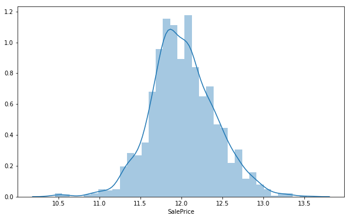

```python
plt.figure(figsize=[10,6])
sns.distplot(np.log(total3.loc[total3.SalePrice.isnull()!=True].SalePrice))
```

```python
total3 = total3.replace({'Street': {'Pave': 1, 'Grvl': 0 },
                             'FireplaceQu': {'Ex': 5,
                                            'Gd': 4,
                                            'TA': 3,
                                            'Fa': 2,
                                            'Po': 1,
                                            'None': 0
                                            },
                             'Fence':      {'GdPrv': 4,
                                            'GdWo': 3,
                                            'MnPrv': 2,
                                            'MnWw': 1,
                                            'None': 0},
                             'ExterQual':  {'Ex': 5,
                                            'Gd': 4,
                                            'TA': 3,
                                            'Fa': 2,
                                            'Po': 1
                                            },
                             'ExterCond':  {'Ex': 5,
                                            'Gd': 4,
                                            'TA': 3,
                                            'Fa': 2,
                                            'Po': 1
                                            },
                             'BsmtQual':   {'Ex': 5,
                                            'Gd': 4,
                                            'TA': 3,
                                            'Fa': 2,
                                            'Po': 1,
                                            'None': 0},
                            'BsmtExposure':{'Gd': 3,
                                            'Av': 2,
                                            'Mn': 1,
                                            'No': 0,
                                            'None': 0},
                             'BsmtCond':   {'Ex': 5,
                                            'Gd': 4,
                                            'TA': 3,
                                            'Fa': 2,
                                            'Po': 1,
                                            'None': 0},
                             'GarageQual': {'Ex': 5,
                                            'Gd': 4,
                                            'TA': 3,
                                            'Fa': 2,
                                            'Po': 1,
                                            'None': 0},
                             'GarageCond': {'Ex': 5,
                                            'Gd': 4,
                                            'TA': 3,
                                            'Fa': 2,
                                            'Po': 1,
                                            'None': 0},
                            'KitchenQual': {'Ex': 5,
                                            'Gd': 4,
                                            'TA': 3,
                                            'Fa': 2,
                                            'Po': 1},
                             'Functional': {'Typ': 7,
                                            'Min1':6,
                                            'Min2':5,
                                            'Mod': 4,
                                            'Maj1':3,
                                            'Maj2':2,
                                            'Sev': 1,
                                            'Sal': 0},
                             'BsmtFinType1': {'GLQ' : 6,
                                              'ALQ' : 5,
                                              'BLQ' : 4,
                                              'Rec' : 3,
                                              'LwQ' : 2,
                                              'Unf' : 1,
                                              'None': 0},
                            'BsmtFinType2': {'GLQ' : 6,
                                              'ALQ' : 5,
                                              'BLQ' : 4,
                                              'Rec' : 3,
                                              'LwQ' : 2,
                                              'Unf' : 1,
                                              'None': 0},
                             'HeatingQC':   {'Ex': 5,
                                            'Gd': 4,
                                            'TA': 3,
                                            'Fa': 2,
                                            'Po': 1
                                            },
                            'PoolQC' :    {'Ex': 4,
                                            'Gd': 3,
                                            'Fa': 2,
                                            'None': 1
                                            }
                            })
```

```python
def NormVariable(x):
    x= (x - np.mean(x))/(max(x)-min(x))
    return(x)
```

```python
def ScaleVariable(x):
    x = x/max(x)
    return(x)
```

```python
total4 = total3[:]
```

```python
total4.columns
```

```
Index(['MSSubClass', 'MSZoning', 'LotFrontage', 'LotArea', 'Street', 'Alley',
       'LotShape', 'LandContour', 'LotConfig', 'LandSlope', 'Neighborhood',
       'Condition1', 'Condition2', 'BldgType', 'HouseStyle', 'OverallQual',
       'OverallCond', 'HAge', 'RoofStyle', 'RoofMatl', 'Exterior1st',
       'Exterior2nd', 'MasVnrType', 'MasVnrArea', 'ExterQual', 'ExterCond',
       'Foundation', 'BsmtQual', 'BsmtCond', 'BsmtExposure', 'BsmtFinType1',
       'BsmtFinSF1', 'BsmtFinType2', 'BsmtFinSF2', 'BsmtUnfSF', 'TotalBsmtSF',
       'Heating', 'HeatingQC', 'CentralAir', 'Electrical', '1stFlrSF',
       '2ndFlrSF', 'LowQualFinSF', 'GrLivArea', 'BsmtFullBath', 'BsmtHalfBath',
       'FullBath', 'HalfBath', 'BedroomAbvGr', 'KitchenAbvGr', 'KitchenQual',
       'TotRmsAbvGrd', 'Functional', 'Fireplaces', 'FireplaceQu', 'GarageType',
       'GrAge', 'GarageFinish', 'GarageCars', 'GarageArea', 'GarageQual',
       'GarageCond', 'PavedDrive', 'WoodDeckSF', 'OpenPorchSF',
       'EnclosedPorch', '3SsnPorch', 'ScreenPorch', 'PoolArea', 'PoolQC',
       'Fence', 'MiscFeature', 'MiscVal', 'MoSold', 'SoldAge', 'SaleType',
       'SaleCondition', 'SalePrice'],
      dtype='object')
```

```python
for col in total4[['MSSubClass', 'MSZoning', 'Street','LotShape', 'LandContour', 'LotConfig', 'LandSlope', 'Neighborhood',
    'Condition1', 'Condition2', 'BldgType', 'HouseStyle', 'RoofStyle', 'RoofMatl', 'Exterior1st','Exterior2nd', 'MiscFeature',
    'MasVnrType','Foundation',  'Heating', 'Electrical','GarageType','GarageFinish', 'PavedDrive','MoSold', 'SaleType',
                   'SaleCondition']]:
    col = pd.get_dummies(total4[col])
    total4 = total4.merge(col, left_index=True, right_index=True)
```

```python
total4 = total4.drop(['MSSubClass', 'MSZoning', 'Street','LotShape', 'LandContour', 'LotConfig', 'LandSlope', 'Neighborhood',
    'Condition1', 'Condition2', 'BldgType', 'HouseStyle', 'RoofStyle', 'RoofMatl', 'Exterior1st','Exterior2nd',
    'MasVnrType','Foundation',  'Heating', 'Electrical','GarageType','GarageFinish', 'PavedDrive','MoSold', 'SaleType',
                      'SaleCondition'], axis=1)
```

```python
for col in total4[[]]:
    total4[col] = NormVariable(pd.to_numeric(total4[col]))
```

```python
for col in total4[['ExterQual', 'ExterCond', 'BsmtQual', 'BsmtCond','BsmtExposure', 'BsmtFinType1', 'BsmtFinType2',
                  'PoolQC','KitchenQual','GarageQual','GarageCond','Fence','OverallQual','OverallCond','Functional',
                   'FireplaceQu','HeatingQC', 'TotRmsAbvGrd','Fireplaces','GarageCars','Fireplaces', 'BedroomAbvGr']]:
    total4[col] = ScaleVariable(pd.to_numeric(total4[col]))
```

```python
for col in total4[['SalePrice','SoldAge','GrAge','HAge','MiscVal','LotFrontage', 'LotArea','MasVnrArea','PoolArea',
                   'GrLivArea','GarageArea','WoodDeckSF', 'OpenPorchSF','EnclosedPorch', '3SsnPorch', 'ScreenPorch',
                   'BsmtFinSF1', 'BsmtFinSF2','BsmtUnfSF', 'TotalBsmtSF','1stFlrSF','2ndFlrSF', 'LowQualFinSF']]:
    total4[col] = np.log(total4[col]+1)
```

```python
test2 = total4.loc[total4.SalePrice.isnull()==True]
```

```python
train2 = total4.loc[total4.SalePrice.isnull()==False]
```

```python
from sklearn.linear_model import RidgeCV, LassoCV, LassoLarsCV, ElasticNetCV,LinearRegression
from sklearn.ensemble import  GradientBoostingRegressor
from sklearn.model_selection import KFold,cross_val_score
```

```python
import xgboost as xgb
```

```python
ytrain=train2.SalePrice
```

```python
train3 = train2[:]
```

```python
train3 = train3.drop('SalePrice',1)
```

```python
test3 = test2[:]
```

```python
test3 = test3.drop('SalePrice',1)
```

```python
kfolds = KFold(n_splits=10, shuffle=True, random_state=35)
```

```python
def rmse_cv(model):
    rmse= np.sqrt(-cross_val_score(model, train3, ytrain, scoring="neg_mean_squared_error", cv = kfolds))
    return(rmse)
```

## Lasso

```python
model_lasso = LassoCV(alphas = [1, 0.1, 0.05, 0.001, 0.0004, 0.0005, 0.0006, 0.0007, 0.0008, 0.0009], cv=kfolds).fit(train3, ytrain)
```

```python
rmse_cv(model_lasso).mean()
```

```
0.11318774106854175
```

```python
coef = pd.Series(model_lasso.coef_, index = train3.columns)
```

```python
print("Lasso picked " + str(sum(coef != 0)) + " variables and eliminated the other " +  str(sum(coef == 0)) + " variables")
```

```
Lasso picked 110 variables and eliminated the other 142 variables
```

```python
imp_coef = pd.concat([coef.sort_values().head(10),
                     coef.sort_values().tail(10)])
```

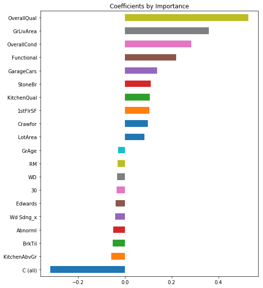

```python
plt.rcParams['figure.figsize'] = (8.0, 10.0)
imp_coef.plot(kind = "barh")
plt.title("Coefficients by Importance")
```

```python
lasso_preds = np.expm1(model_lasso.predict(test3))-1
```

```python
solution = pd.DataFrame({"id":test.Id, "SalePrice":lasso_preds})
solution.to_csv("submit_lasso.csv", index = False)
```

## Ridge

```python
Ridge = RidgeCV(alphas = [0.01,0.1,0.5,1,3,5,10,20,30,50,100]).fit(train3, ytrain)
```

```python
rmse_cv(Ridge).mean()
```

```
0.11620765380712825
```

```python
ridge_preds = np.expm1(Ridge.predict(test3))-1
```

```python
solution = pd.DataFrame({"id":test.Id, "SalePrice":ridge_preds})
solution.to_csv("submit_ridge.csv", index = False)
```

## ElasticNet

This time I am going to try Elastic-net, which is useful when there are multiple features which are correlated with one another. Lasso is likely to pick one of these at random, while elastic-net is likely to pick both.

```python
Enet = ElasticNetCV(alphas=[0.0001, 0.0005, 0.001, 0.01, 0.1, 1, 10], l1_ratio=[.01, .1, .5, .9, .99], max_iter=5000, cv=kfolds).fit(train3, ytrain)
```

```python
rmse_cv(Enet).mean()
```

```
0.11349490309407777
```

```python
enet_preds = np.expm1(Enet.predict(test3))-1
```

```python
solution = pd.DataFrame({"id":test.Id, "SalePrice":enet_preds})
solution.to_csv("submit_enet.csv", index = False)
```

## Gradient Boosting Regressor

```python
gbmodel = GradientBoostingRegressor(learning_rate=0.05, loss='huber', min_samples_split=10, n_estimators=3000,
                                       random_state=35).fit(train3, ytrain)
```

```python
rmse_cv(gbmodel).mean()
```

```
0.12006412503895551
```

```python
gb_preds = np.expm1(gbmodel.predict(test3))-1
```

## XGBoost

Lastly I tried to use XGBoost in my dataset like other models, however it returned with duplicated column name error. So for trying this model, I had to find duplicated columns, so I used a function I got from [this link in Github](https://github.com/pandas-dev/pandas/issues/11250) and with this function I found which columns were duplicated. And then I changed them and created a new train and test dataset. With this I trained XGBoost, but it did not provide better result than regularized linear models.

```python
def duplicate_columns(frame):
    groups = frame.columns.to_series().groupby(frame.dtypes).groups
    dups = []

    for t, v in groups.items():

        cs = frame[v].columns
        vs = frame[v]
        lcs = len(cs)

        for i in range(lcs):
            iv = vs.iloc[:,i].tolist()
            for j in range(i+1, lcs):
                jv = vs.iloc[:,j].tolist()
                if iv == jv:
                    dups.append(cs[i])
                    break

    return dups
```

```python
duplicate_columns(total4)
```

```
[90, 'Stone_x', 'Stone_x', 'Stone_y', 'Stone_y']
```

```python
total4.columns.values
```

```
array(['LotFrontage', 'LotArea', 'Alley', 'OverallQual', 'OverallCond',
       'HAge', 'MasVnrArea', 'ExterQual', 'ExterCond', 'BsmtQual',
       'BsmtCond', 'BsmtExposure', 'BsmtFinType1', 'BsmtFinSF1',
       'BsmtFinType2', 'BsmtFinSF2', 'BsmtUnfSF', 'TotalBsmtSF',
       'HeatingQC', 'CentralAir', '1stFlrSF', '2ndFlrSF', 'LowQualFinSF',
       'GrLivArea', 'BsmtFullBath', 'BsmtHalfBath', 'FullBath',
       'HalfBath', 'BedroomAbvGr', 'KitchenAbvGr', 'KitchenQual',
       'TotRmsAbvGrd', 'Functional', 'Fireplaces', 'FireplaceQu', 'GrAge',
       'GarageCars', 'GarageArea', 'GarageQual', 'GarageCond',
       'WoodDeckSF', 'OpenPorchSF', 'EnclosedPorch', '3SsnPorch',
       'ScreenPorch', 'PoolArea', 'PoolQC', 'Fence', 'MiscFeature',
       'MiscVal', 'SoldAge', 'SalePrice', 20, 30, 40, 45, 50, 60, 70, 75,
       80, 85, 90, 120, 150, 160, 180, 190, 'C (all)', 'FV', 'RH', 'RL',
       'RM', '0_x', '1_x', 'IR1', 'IR2', 'IR3', 'Reg', 'Bnk', 'HLS',
       'Low', 'Lvl', 'Corner', 'CulDSac', 'FR2', 'FR3', 'Inside', 'Gtl',
       'Mod', 'Sev', 'Blmngtn', 'Blueste', 'BrDale', 'BrkSide', 'ClearCr',
       'CollgCr', 'Crawfor', 'Edwards', 'Gilbert', 'IDOTRR', 'MeadowV',
       'Mitchel', 'NAmes', 'NPkVill', 'NWAmes', 'NoRidge', 'NridgHt',
       'OldTown', 'SWISU', 'Sawyer', 'SawyerW', 'Somerst', 'StoneBr',
       'Timber', 'Veenker', 'Artery_x', 'Feedr_x', 'Norm_x', 'PosA_x',
       'PosN_x', 'RRAe', 'RRAn_x', 'RRNe', 'RRNn_x', 'Artery_y',
       'Feedr_y', 'Norm_y', 'PosA_y', 'PosN_y', 'RRAn_y', 'RRNn_y',
       '1Fam', '2fmCon', 'Duplex', 'Twnhs', 'TwnhsE', '1.5Fin', '1.5Unf',
       '1Story', '2.5Fin', '2.5Unf', '2Story', 'SFoyer', 'SLvl', 'Flat',
       'Gable', 'Gambrel', 'Hip', 'Mansard', 'Shed', 'CompShg', 'Membran',
       'Metal', 'Roll', 'Tar&Grv', 'WdShake', 'WdShngl', 'AsbShng_x',
       'AsphShn_x', 'BrkComm', 'BrkFace_x', 'CBlock_x', 'CemntBd',
       'HdBoard_x', 'ImStucc_x', 'MetalSd_x', 'Plywood_x', 'Stone_x',
       'Stucco_x', 'VinylSd_x', 'Wd Sdng_x', 'WdShing', 'AsbShng_y',
       'AsphShn_y', 'Brk Cmn', 'BrkFace_y', 'CBlock_y', 'CmentBd',
       'HdBoard_y', 'ImStucc_y', 'MetalSd_y', 'Other', 'Plywood_y',
       'Stone_y', 'Stucco_y', 'VinylSd_y', 'Wd Sdng_y', 'Wd Shng', '0_y',
       '1_y', 'BrkCmn', 'BrkFace', 'None_x', 'Stone_x', 'BrkTil',
       'CBlock', 'PConc', 'Slab', 'Stone_y', 'Wood', 'Floor', 'GasA',
       'GasW', 'Grav', 'OthW', 'Wall', 'FuseA', 'FuseF', 'FuseP', 'Mix',
       'SBrkr', '2Types', 'Attchd', 'Basment', 'BuiltIn', 'CarPort',
       'Detchd', 'None_y', 'Fin', 'None', 'RFn', 'Unf', 'N', 'P', 'Y', 1,
       2, 3, 4, 5, 6, 7, 8, 9, 10, 11, 12, 'COD', 'CWD', 'Con', 'ConLD',
       'ConLI', 'ConLw', 'New', 'Oth', 'WD', 'Abnorml', 'AdjLand',
       'Alloca', 'Family', 'Normal', 'Partial'], dtype=object)
```

```python
total5 = total4[:]
```

```python
total5.columns = (['LotFrontage', 'LotArea', 'Alley', 'OverallQual', 'OverallCond',
       'HAge', 'MasVnrArea', 'ExterQual', 'ExterCond', 'BsmtQual',
       'BsmtCond', 'BsmtExposure', 'BsmtFinType1', 'BsmtFinSF1',
       'BsmtFinType2', 'BsmtFinSF2', 'BsmtUnfSF', 'TotalBsmtSF',
       'HeatingQC', 'CentralAir', '1stFlrSF', '2ndFlrSF', 'LowQualFinSF',
       'GrLivArea', 'BsmtFullBath', 'BsmtHalfBath', 'FullBath',
       'HalfBath', 'BedroomAbvGr', 'KitchenAbvGr', 'KitchenQual',
       'TotRmsAbvGrd', 'Functional', 'Fireplaces', 'FireplaceQu', 'GrAge',
       'GarageCars', 'GarageArea', 'GarageQual', 'GarageCond',
       'WoodDeckSF', 'OpenPorchSF', 'EnclosedPorch', '3SsnPorch',
       'ScreenPorch', 'PoolArea', 'PoolQC', 'Fence', 'MiscFeature',
       'MiscVal', 'SoldAge', 'SalePrice', 20, 30, 40, 45, 50, 60, 70, 75,
       80, 85, 90, 120, 150, 160, 180, 190, 'C (all)', 'FV', 'RH', 'RL',
       'RM', '0_x', '1_x', 'IR1', 'IR2', 'IR3', 'Reg', 'Bnk', 'HLS',
       'Low', 'Lvl', 'Corner', 'CulDSac', 'FR2', 'FR3', 'Inside', 'Gtl',
       'Mod', 'Sev', 'Blmngtn', 'Blueste', 'BrDale', 'BrkSide', 'ClearCr',
       'CollgCr', 'Crawfor', 'Edwards', 'Gilbert', 'IDOTRR', 'MeadowV',
       'Mitchel', 'NAmes', 'NPkVill', 'NWAmes', 'NoRidge', 'NridgHt',
       'OldTown', 'SWISU', 'Sawyer', 'SawyerW', 'Somerst', 'StoneBr',
       'Timber', 'Veenker', 'Artery_x', 'Feedr_x', 'Norm_x', 'PosA_x',
       'PosN_x', 'RRAe', 'RRAn_x', 'RRNe', 'RRNn_x', 'Artery_y',
       'Feedr_y', 'Norm_y', 'PosA_y', 'PosN_y', 'RRAn_y', 'RRNn_y',
       '1Fam', '2fmCon', 'Duplex', 'Twnhs', 'TwnhsE', '1.5Fin', '1.5Unf',
       '1Story', '2.5Fin', '2.5Unf', '2Story', 'SFoyer', 'SLvl', 'Flat',
       'Gable', 'Gambrel', 'Hip', 'Mansard', 'Shed', 'CompShg', 'Membran',
       'Metal', 'Roll', 'Tar&Grv', 'WdShake', 'WdShngl', 'AsbShng_x',
       'AsphShn_x', 'BrkComm', 'BrkFace_x', 'CBlock_x', 'CemntBd',
       'HdBoard_x', 'ImStucc_x', 'MetalSd_x', 'Plywood_x', 'Stone_x1',
       'Stucco_x', 'VinylSd_x', 'Wd Sdng_x', 'WdShing', 'AsbShng_y',
       'AsphShn_y', 'Brk Cmn', 'BrkFace_y', 'CBlock_y', 'CmentBd',
       'HdBoard_y', 'ImStucc_y', 'MetalSd_y', 'Other', 'Plywood_y',
       'Stone_y1', 'Stucco_y', 'VinylSd_y', 'Wd Sdng_y', 'Wd Shng', '0_y',
       '1_y', 'BrkCmn', 'BrkFace', 'None_x', 'Stone_x', 'BrkTil',
       'CBlock', 'PConc', 'Slab', 'Stone_y', 'Wood', 'Floor', 'GasA',
       'GasW', 'Grav', 'OthW', 'Wall', 'FuseA', 'FuseF', 'FuseP', 'Mix',
       'SBrkr', '2Types', 'Attchd', 'Basment', 'BuiltIn', 'CarPort',
       'Detchd', 'None_y', 'Fin', 'None', 'RFn', 'Unf', 'N', 'P', 'Y', 1,
       2, 3, 4, 5, 6, 7, 8, 9, 10, 11, 12, 'COD', 'CWD', 'Con', 'ConLD',
       'ConLI', 'ConLw', 'New', 'Oth', 'WD', 'Abnorml', 'AdjLand',
       'Alloca', 'Family', 'Normal', 'Partial'])
```

```python
testxgb = total5.loc[total5.SalePrice.isnull()==True]
```

```python
testxgb.drop('SalePrice',1, inplace=True)
```

```python
trainxgb = total5.loc[total5.SalePrice.isnull()==False]
```

```python
trainxgb.drop('SalePrice',1, inplace=True)
```

```python
def rmse_cv1(model):
    rmse= np.sqrt(-cross_val_score(model, trainxgb, ytrain, scoring="neg_mean_squared_error", cv = kfolds))
    return(rmse)
```

```python
model_xgb = xgb.XGBRegressor(n_estimators=360, max_depth=2, learning_rate=0.1).fit(trainxgb, ytrain)
```

```python
rmse_cv1(model_xgb).mean()
```

```
0.1191643214553407
```

```python
xgb_preds = np.expm1(model_xgb.predict(testxgb))-1
```

It seems Lasso had the best results, it was also proven by Kaggle via submission scores. However, as my last submission, I calculate average of all predictions generated by models and submit it. After submission it scored as 0.12135.

```python
pred = (lasso_preds + ridge_preds + enet_preds + xgb_preds + gb_preds)/5
```

```python
solution = pd.DataFrame({"id":test.Id, "SalePrice":pred})
solution.to_csv("submit_comb.csv", index = False)
```